# People’s feelings of life prediction using multiple linear regression models: A study on GSS (General Social Survey) 2017.

# variables that could be deleted: sex, living_arrangement, province

|  | #Df | LogLik | Df | Chisq | Pr(>Chisq) |
| --- | --- | --- | --- | --- | --- |
| 1 | 69 | -10778.62 | NA | NA | NA |
| 2 | 68 | -10784.94 | -1 | 12.6322 | 0.000379158 |

|  | #Df | LogLik | Df | Chisq | Pr(>Chisq) |
| --- | --- | --- | --- | --- | --- |
| 1 | 69 | -10778.62 | NA | NA | NA |
| 2 | 58 | -10790.50 | -11 | 23.75672 | 0.01379875 |

|  | #Df | LogLik | Df | Chisq | Pr(>Chisq) |
| --- | --- | --- | --- | --- | --- |
| 1 | 69 | -10778.62 | NA | NA | NA |
| 2 | 49 | -10802.50 | -20 | 47.75504 | 0.0004603789 |

# Variables that contain NA data values:age_first_child, marital_status, aboriginal, education, average_hours_worked, self health, self mental health, occupation

However, many variables (i.e. age_first_child, marital_status, aboriginal, education, average_hours_worked, self_rated_health, self_rated_mental_health and occupation) contain missing values (NA). It could not simply be deleted because NA in these variables are meaningful. For example, the NA in age_first _child is a way to show that person may not have a child. It results in the inconsistency in the quantity of data for different variables and hence unable to use likelihood ratio tests in order to do the variable selection. We decided to include those variables that contain NA also in the regression model temporarily, and named the model “reg_finaltem”.

# To conclude the above info, the temporary best fit model after ratio likelihood test:

|  | #Df | LogLik | Df | Chisq | Pr(>Chisq) |
| --- | --- | --- | --- | --- | --- |
| 1 | 69 | -10778.62 | NA | NA | NA |
| 2 | 43 | -10810.31 | -26 | 63.37123 | 5.811145e-05 |

```
##
## Call:
## lm(formula = feelings_life ~ age + total_children + age_first_child +
##     marital_status + aboriginal + education + average_hours_worked +
##     self_rated_health + self_rated_mental_health + occupation,
##     data = data1)
##
## Residuals:
##     Min      1Q  Median      3Q     Max
## -8.3939 -0.7163  0.0704  0.8595  5.8309
##
## Coefficients:
##                                                                        Estimate
## (Intercept)                                                            5.447393
## age                                                                   -0.006613
## total_children                                                         0.006648
## age_first_child                                                        0.011352
## marital_statusLiving common-law                                        0.419534
## marital_statusMarried                                                  0.557187
## marital_statusSeparated                                               -0.168788
## marital_statusSingle, never married                                   -0.193203
## marital_statusWidowed                                                 -0.189569
## aboriginalNo                                                          -0.668614
## aboriginalYes                                                         -0.580830
## educationCollege, CEGEP or other non-university certificate or di...   0.060589
## educationHigh school diploma or a high school equivalency certificate  0.063334
## educationLess than high school diploma or its equivalent               0.257015
## educationTrade certificate or diploma                                  0.079161
## educationUniversity certificate or diploma below the bachelor's level  0.016683
## educationUniversity certificate, diploma or degree above the bach...   0.019772
## average_hours_worked0.1 to 29.9 hours                                  0.525090
## average_hours_worked30.0 to 40.0 hours                                 0.494149
## average_hours_worked40.1 to 50.0 hours                                 0.547719
## average_hours_worked50.1 hours and more                                0.582609
## average_hours_workedDon't know                                         0.259202
## self_rated_healthExcellent                                             1.247117
## self_rated_healthFair                                                  0.770199
## self_rated_healthGood                                                  0.913127
## self_rated_healthPoor                                                  0.243506
## self_rated_healthVery good                                             1.050937
```

[output cut: 179 more lines]

```
## occupationNatural and applied sciences and related occupations
## occupationNatural resources, agriculture and related production oc...
## occupationOccupations in art, culture, recreation and sport
## occupationOccupations in education, law and social, community and ...
## occupationOccupations in manufacturing and utilities
## occupationSales and service occupations
## occupationTrades, transport and equipment operators and related oc... .
## occupationUncodable
## ---
## Signif. codes:  0 '***' 0.001 '**' 0.01 '*' 0.05 '.' 0.1 ' ' 1
##
## Residual standard error: 1.243 on 6578 degrees of freedom
##   (13982 observations deleted due to missingness)
## Multiple R-squared:  0.2816, Adjusted R-squared:  0.2771
## F-statistic: 62.88 on 41 and 6578 DF,  p-value: < 2.2e-16
```

To find out whether the variables which contain NA have close linear relationships to feelings of life, we decide to do two steps. Firstly, we check the summary table of “reg_finaltem”, pull out the variables that have p-values greater than 0.05. Secondly, graph and analyze each of them separately to double-check whether they should be deleted.

# step1: see the summary of reg_finaltem and select the p-value greater than 0.05’s variables

```
##
## Call:
## lm(formula = feelings_life ~ age + total_children + age_first_child +
##     marital_status + aboriginal + education + average_hours_worked +
##     self_rated_health + self_rated_mental_health + occupation,
##     data = data1)
##
## Residuals:
##     Min      1Q  Median      3Q     Max
## -8.3939 -0.7163  0.0704  0.8595  5.8309
##
## Coefficients:
##                                                                        Estimate
## (Intercept)                                                            5.447393
## age                                                                   -0.006613
## total_children                                                         0.006648
## age_first_child                                                        0.011352
## marital_statusLiving common-law                                        0.419534
## marital_statusMarried                                                  0.557187
## marital_statusSeparated                                               -0.168788
## marital_statusSingle, never married                                   -0.193203
## marital_statusWidowed                                                 -0.189569
## aboriginalNo                                                          -0.668614
## aboriginalYes                                                         -0.580830
## educationCollege, CEGEP or other non-university certificate or di...   0.060589
## educationHigh school diploma or a high school equivalency certificate  0.063334
## educationLess than high school diploma or its equivalent               0.257015
## educationTrade certificate or diploma                                  0.079161
## educationUniversity certificate or diploma below the bachelor's level  0.016683
## educationUniversity certificate, diploma or degree above the bach...   0.019772
## average_hours_worked0.1 to 29.9 hours                                  0.525090
## average_hours_worked30.0 to 40.0 hours                                 0.494149
## average_hours_worked40.1 to 50.0 hours                                 0.547719
## average_hours_worked50.1 hours and more                                0.582609
## average_hours_workedDon't know                                         0.259202
## self_rated_healthExcellent                                             1.247117
## self_rated_healthFair                                                  0.770199
## self_rated_healthGood                                                  0.913127
## self_rated_healthPoor                                                  0.243506
## self_rated_healthVery good                                             1.050937
```

[output cut: 179 more lines]

```
## occupationNatural and applied sciences and related occupations
## occupationNatural resources, agriculture and related production oc...
## occupationOccupations in art, culture, recreation and sport
## occupationOccupations in education, law and social, community and ...
## occupationOccupations in manufacturing and utilities
## occupationSales and service occupations
## occupationTrades, transport and equipment operators and related oc... .
## occupationUncodable
## ---
## Signif. codes:  0 '***' 0.001 '**' 0.01 '*' 0.05 '.' 0.1 ' ' 1
##
## Residual standard error: 1.243 on 6578 degrees of freedom
##   (13982 observations deleted due to missingness)
## Multiple R-squared:  0.2816, Adjusted R-squared:  0.2771
## F-statistic: 62.88 on 41 and 6578 DF,  p-value: < 2.2e-16
```

```
##
## Call:
## lm(formula = feelings_life ~ age + total_children + age_first_child +
##     marital_status + aboriginal + education + average_hours_worked +
##     self_rated_health + self_rated_mental_health + occupation,
##     data = data1)
##
## Residuals:
##     Min      1Q  Median      3Q     Max
## -8.3939 -0.7163  0.0704  0.8595  5.8309
##
## Coefficients:
##                                                                        Estimate
## (Intercept)                                                            5.447393
## age                                                                   -0.006613
## total_children                                                         0.006648
## age_first_child                                                        0.011352
## marital_statusLiving common-law                                        0.419534
## marital_statusMarried                                                  0.557187
## marital_statusSeparated                                               -0.168788
## marital_statusSingle, never married                                   -0.193203
## marital_statusWidowed                                                 -0.189569
## aboriginalNo                                                          -0.668614
## aboriginalYes                                                         -0.580830
## educationCollege, CEGEP or other non-university certificate or di...   0.060589
## educationHigh school diploma or a high school equivalency certificate  0.063334
## educationLess than high school diploma or its equivalent               0.257015
## educationTrade certificate or diploma                                  0.079161
## educationUniversity certificate or diploma below the bachelor's level  0.016683
## educationUniversity certificate, diploma or degree above the bach...   0.019772
## average_hours_worked0.1 to 29.9 hours                                  0.525090
## average_hours_worked30.0 to 40.0 hours                                 0.494149
## average_hours_worked40.1 to 50.0 hours                                 0.547719
## average_hours_worked50.1 hours and more                                0.582609
## average_hours_workedDon't know                                         0.259202
## self_rated_healthExcellent                                             1.247117
## self_rated_healthFair                                                  0.770199
## self_rated_healthGood                                                  0.913127
## self_rated_healthPoor                                                  0.243506
## self_rated_healthVery good                                             1.050937
```

[output cut: 179 more lines]

```
## occupationNatural and applied sciences and related occupations
## occupationNatural resources, agriculture and related production oc...
## occupationOccupations in art, culture, recreation and sport
## occupationOccupations in education, law and social, community and ...
## occupationOccupations in manufacturing and utilities
## occupationSales and service occupations
## occupationTrades, transport and equipment operators and related oc... .
## occupationUncodable
## ---
## Signif. codes:  0 '***' 0.001 '**' 0.01 '*' 0.05 '.' 0.1 ' ' 1
##
## Residual standard error: 1.243 on 6578 degrees of freedom
##   (13982 observations deleted due to missingness)
## Multiple R-squared:  0.2816, Adjusted R-squared:  0.2771
## F-statistic: 62.88 on 41 and 6578 DF,  p-value: < 2.2e-16
```

# secondly, graph and analyse each of the variables that have p-value larger than 0.05 in reg_finaltem separately.

# graph of aboriginal

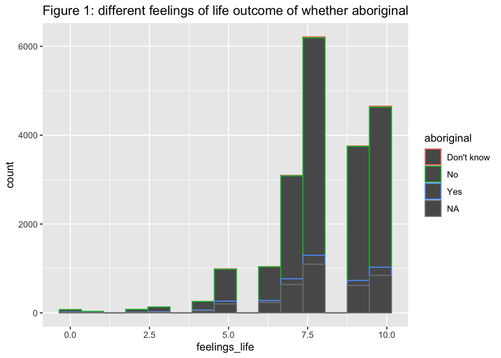

```
##
## Call:
## lm(formula = data$feelings_life ~ data1$aboriginal)
##
## Residuals:
##     Min      1Q  Median      3Q     Max
## -8.1285 -1.1285 -0.1285  0.8715  2.2005
##
## Coefficients:
##                     Estimate Std. Error t value Pr(>|t|)
## (Intercept)          7.88750    0.18316  43.064   <2e-16 ***
## data1$aboriginalNo   0.24095    0.18362   1.312    0.189
## data1$aboriginalYes -0.08801    0.19228  -0.458    0.647
## ---
## Signif. codes:  0 '***' 0.001 '**' 0.01 '*' 0.05 '.' 0.1 ' ' 1
##
## Residual standard error: 1.638 on 16601 degrees of freedom
##   (3998 observations deleted due to missingness)
## Multiple R-squared:  0.001899,   Adjusted R-squared:  0.001779
## F-statistic: 15.79 on 2 and 16601 DF,  p-value: 1.406e-07
```

We were predicted that the aboriginal people have less happiness index than the people who are not aboriginal. The histogram indicated that the non-aboriginal people have a larger amount of the Happiness index. This shows that aboriginal people are not as happy as non-aboriginal people. However, in the summary of the regression line, the P-value of both aboriginal-No and aboriginal-Yes are larger than 0.05, which suggests we do not include the aboriginal variable into the model. This might because there are potential lurking variables to make them have larger p-value.

# graph of education

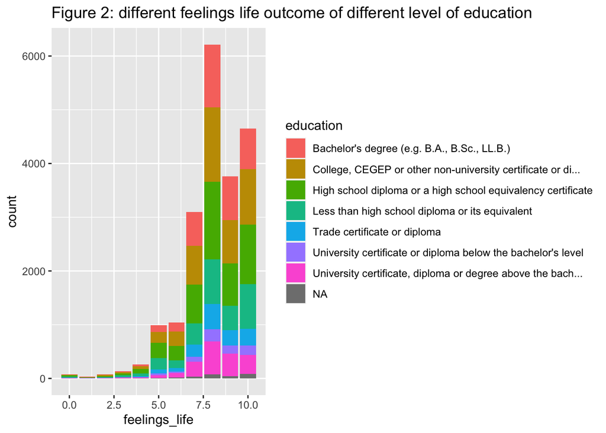

```
##
## Call:
## lm(formula = data1$feelings_life ~ data1$education)
##
## Residuals:
##     Min      1Q  Median      3Q     Max
## -8.2170 -1.0063 -0.0570  0.9937  1.9937
##
## Coefficients:
##                                                                             Estimate
## (Intercept)                                                                  8.17091
## data1$educationCollege, CEGEP or other non-university certificate or di...  -0.08737
## data1$educationHigh school diploma or a high school equivalency certificate -0.16465
## data1$educationLess than high school diploma or its equivalent              -0.11386
## data1$educationTrade certificate or diploma                                 -0.08315
## data1$educationUniversity certificate or diploma below the bachelor's level  0.04612
## data1$educationUniversity certificate, diploma or degree above the bach...   0.03194
##                                                                             Std. Error
## (Intercept)                                                                    0.02687
## data1$educationCollege, CEGEP or other non-university certificate or di...     0.03629
## data1$educationHigh school diploma or a high school equivalency certificate    0.03583
## data1$educationLess than high school diploma or its equivalent                 0.04032
## data1$educationTrade certificate or diploma                                    0.05054
## data1$educationUniversity certificate or diploma below the bachelor's level    0.06650
## data1$educationUniversity certificate, diploma or degree above the bach...     0.04689
##                                                                             t value
## (Intercept)                                                                 304.137
## data1$educationCollege, CEGEP or other non-university certificate or di...   -2.407
## data1$educationHigh school diploma or a high school equivalency certificate  -4.596
## data1$educationLess than high school diploma or its equivalent               -2.824
## data1$educationTrade certificate or diploma                                  -1.645
## data1$educationUniversity certificate or diploma below the bachelor's level   0.694
## data1$educationUniversity certificate, diploma or degree above the bach...    0.681
##                                                                             Pr(>|t|)
## (Intercept)                                                                  < 2e-16
## data1$educationCollege, CEGEP or other non-university certificate or di...   0.01608
## data1$educationHigh school diploma or a high school equivalency certificate 4.34e-06
## data1$educationLess than high school diploma or its equivalent               0.00475
## data1$educationTrade certificate or diploma                                  0.09995
## data1$educationUniversity certificate or diploma below the bachelor's level  0.48797
## data1$educationUniversity certificate, diploma or degree above the bach...   0.49576
##
## (Intercept)                                                                 ***
## data1$educationCollege, CEGEP or other non-university certificate or di...  *
## data1$educationHigh school diploma or a high school equivalency certificate ***
## data1$educationLess than high school diploma or its equivalent              **
## data1$educationTrade certificate or diploma                                 .
## data1$educationUniversity certificate or diploma below the bachelor's level
## data1$educationUniversity certificate, diploma or degree above the bach...
## ---
## Signif. codes:  0 '***' 0.001 '**' 0.01 '*' 0.05 '.' 0.1 ' ' 1
##
## Residual standard error: 1.641 on 20049 degrees of freedom
##   (546 observations deleted due to missingness)
## Multiple R-squared:  0.001779,   Adjusted R-squared:  0.00148
## F-statistic: 5.954 on 6 and 20049 DF,  p-value: 3.16e-06
```

We want to find out whether different levels of education have a linear relationship with the feelings of life index. Firstly, we drew a bar plot by these two variables, from the graph we can see that each level of education is having approximately the same proportion in each feeling of life index. So we initially concluded that it should not have much influence on people’s feelings of life index. Next, we offered a linear regression model of these two variables and looked at their summary result. Although the p-value of the total model is less than 0.05, nearly half of the variables’ p-value in the data is larger than 0.05. In order to find the best-fitted model, we decided to drop the variable “education” from our final dataset

# graph of average hours worked

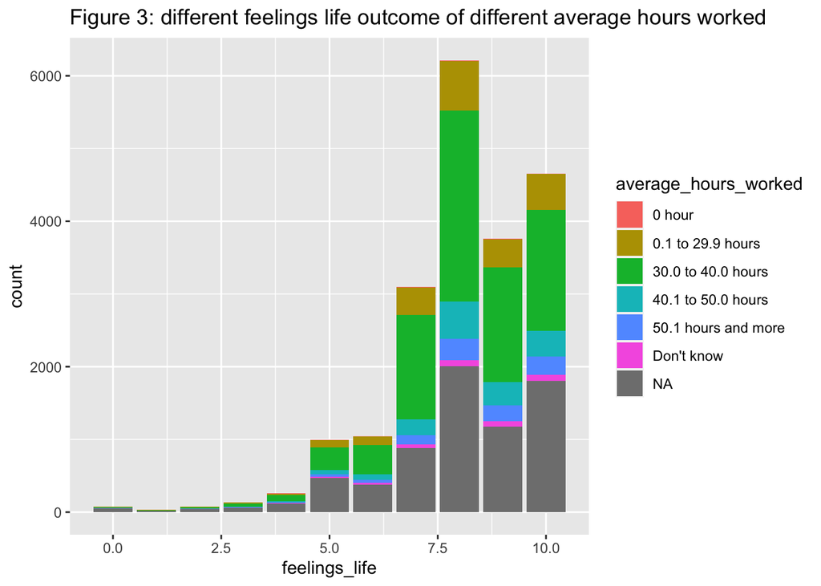

We want to find out whether different average hours worked to have a linear relationship with the feelings of life index. Firstly, we drew a barplot by these two variables, from the graph we can see that each type of average hours worked are having approximately the same proportion in each feeling of life index, and with the large amount of “NA”, in order to find the best-fitted model, we decided to drop variable “average_hours_worked” from our final dataset.

From the summary table of “reg_finaltem”, we can find out that coefficients of the variable “aboriginal”, “education” and “average_hours_worked” are not statistically significant at 5% significance level. Also, we found that in the graphs of “aboriginal”, “education” and “average_hours_worked” also shows that these three are not connected to the feelings of life. Therefore, we decide to remove them from the temporarily best fit model and conclude our final multiple linear regression model with the following formula:

Feelings_life = β0 + β1age + β2total_children + β3age_first_child + β4 marital_status Living Common-Law + β5 marital_status Married + …+ β8 marital_status Widowed + β9 self_rated_health Excellent +…+β13 self_rated_health Poor + β14 self_rated_mental_health Excellent + … + β18 Self_rated_mental_health Poor.

In other words, our model reveals that happiness is associated with ages, the total number of children the one has, the age of the one’s first child, the marital status of the one, the physical and mental health rate of the one on average. We use “age” and “age_first_child” as a numerical variable rather than age-groups because by doing in this way, it would be more clearly to infer that a one-year increase in age of the one or his/her first child is associated with a specific level of changing in happiness on average holding everything else constant. Changing “age” and “age_first_child” into age-groups is nothing more than turning the change of a specific year into the average difference between two age-groups. In addition, this model is a built-in RStudio. The Variables “age”, “total_children”, and “age_first_child” are numerical variables and the rest are categorical variables. In specific, a variable named “marital_status” has 6 categorical variables, the reference categorical variable in the regression is “Divorced”. Variables named “self_rated_health” and “self_rated_mental_health” both have 6 categorical variables as well, and their reference categorical variable in the regression is “Don’t know”. The categorical variable will become 1 if one belongs to that category, otherwise, the categorical variable is 0. The coefficients of each variable are shown in the table below.

```
##
## Call:
## lm(formula = feelings_life ~ age + total_children + age_first_child +
##     marital_status + self_rated_health + self_rated_mental_health,
##     data = data1)
##
## Residuals:
##     Min      1Q  Median      3Q     Max
## -9.0389 -0.7476  0.0898  0.9336  6.5455
##
## Coefficients:
##                                      Estimate Std. Error t value Pr(>|t|)
## (Intercept)                          6.682919   0.359764  18.576  < 2e-16 ***
## age                                 -0.004807   0.002406  -1.998 0.045723 *
## total_children                       0.042409   0.011026   3.846 0.000120 ***
## age_first_child                      0.012311   0.002187   5.630 1.84e-08 ***
## marital_statusLiving common-law      0.435810   0.054178   8.044 9.41e-16 ***
## marital_statusMarried                0.575352   0.040233  14.300  < 2e-16 ***
## marital_statusSeparated             -0.254336   0.069913  -3.638 0.000276 ***
## marital_statusSingle, never married -0.121586   0.061305  -1.983 0.047356 *
## marital_statusWidowed                0.125338   0.051708   2.424 0.015365 *
## self_rated_healthExcellent           0.998966   0.243434   4.104 4.09e-05 ***
## self_rated_healthFair                0.258984   0.244126   1.061 0.288771
## self_rated_healthGood                0.606931   0.242247   2.505 0.012242 *
## self_rated_healthPoor               -0.566158   0.248491  -2.278 0.022719 *
## self_rated_healthVery good           0.805810   0.242487   3.323 0.000893 ***
## self_rated_mental_healthExcellent    0.823468   0.254878   3.231 0.001237 **
## self_rated_mental_healthFair        -1.058217   0.258387  -4.095 4.24e-05 ***
## self_rated_mental_healthGood        -0.095769   0.254336  -0.377 0.706517
## self_rated_mental_healthPoor        -2.497310   0.274793  -9.088  < 2e-16 ***
## self_rated_mental_healthVery good    0.396693   0.254507   1.559 0.119097
## ---
## Signif. codes:  0 '***' 0.001 '**' 0.01 '*' 0.05 '.' 0.1 ' ' 1
##
## Residual standard error: 1.363 on 13548 degrees of freedom
##   (7035 observations deleted due to missingness)
## Multiple R-squared:  0.2867, Adjusted R-squared:  0.2858
## F-statistic: 302.6 on 18 and 13548 DF,  p-value: < 2.2e-16
```

```
##
## Call:
## svyglm(formula = feelings_life ~ age + total_children + age_first_child +
##     marital_status + self_rated_health + self_rated_mental_health,
##     design = feeling.design.srs, family = "gaussian")
##
## Survey design:
## svydesign(id = ~1, data = data1, fpc = fpc.srs)
##
## Coefficients:
##                                      Estimate Std. Error t value Pr(>|t|)
## (Intercept)                          6.682919   0.000000     Inf   <2e-16 ***
## age                                 -0.004807   0.000000    -Inf   <2e-16 ***
## total_children                       0.042409   0.000000     Inf   <2e-16 ***
## age_first_child                      0.012311   0.000000     Inf   <2e-16 ***
## marital_statusLiving common-law      0.435810   0.000000     Inf   <2e-16 ***
## marital_statusMarried                0.575352   0.000000     Inf   <2e-16 ***
## marital_statusSeparated             -0.254336   0.000000    -Inf   <2e-16 ***
## marital_statusSingle, never married -0.121586   0.000000    -Inf   <2e-16 ***
## marital_statusWidowed                0.125338   0.000000     Inf   <2e-16 ***
## self_rated_healthExcellent           0.998966   0.000000     Inf   <2e-16 ***
## self_rated_healthFair                0.258984   0.000000     Inf   <2e-16 ***
## self_rated_healthGood                0.606931   0.000000     Inf   <2e-16 ***
## self_rated_healthPoor               -0.566158   0.000000    -Inf   <2e-16 ***
## self_rated_healthVery good           0.805810   0.000000     Inf   <2e-16 ***
## self_rated_mental_healthExcellent    0.823468   0.000000     Inf   <2e-16 ***
## self_rated_mental_healthFair        -1.058217   0.000000    -Inf   <2e-16 ***
## self_rated_mental_healthGood        -0.095769   0.000000    -Inf   <2e-16 ***
## self_rated_mental_healthPoor        -2.497310   0.000000    -Inf   <2e-16 ***
## self_rated_mental_healthVery good    0.396693   0.000000     Inf   <2e-16 ***
## ---
## Signif. codes:  0 '***' 0.001 '**' 0.01 '*' 0.05 '.' 0.1 ' ' 1
##
## (Dispersion parameter for gaussian family taken to be 1.855153)
##
## Number of Fisher Scoring iterations: 2
```

```
##
## Call:
## svyglm(formula = feelings_life ~ age + total_children + age_first_child +
##     marital_status + self_rated_health + self_rated_mental_health,
##     design = feeling.design.srs, family = "gaussian")
##
## Residuals:
##     Min      1Q  Median      3Q     Max
## -9.0389 -0.7476  0.0898  0.9336  6.5455
##
## Coefficients:
##                                      Estimate Std. Error t value Pr(>|t|)
## (Intercept)                          6.682919   0.359764  18.576  < 2e-16 ***
## age                                 -0.004807   0.002406  -1.998 0.045723 *
## total_children                       0.042409   0.011026   3.846 0.000120 ***
## age_first_child                      0.012311   0.002187   5.630 1.84e-08 ***
## marital_statusLiving common-law      0.435810   0.054178   8.044 9.41e-16 ***
## marital_statusMarried                0.575352   0.040233  14.300  < 2e-16 ***
## marital_statusSeparated             -0.254336   0.069913  -3.638 0.000276 ***
## marital_statusSingle, never married -0.121586   0.061305  -1.983 0.047356 *
## marital_statusWidowed                0.125338   0.051708   2.424 0.015365 *
## self_rated_healthExcellent           0.998966   0.243434   4.104 4.09e-05 ***
## self_rated_healthFair                0.258984   0.244126   1.061 0.288771
## self_rated_healthGood                0.606931   0.242247   2.505 0.012242 *
## self_rated_healthPoor               -0.566158   0.248491  -2.278 0.022719 *
## self_rated_healthVery good           0.805810   0.242487   3.323 0.000893 ***
## self_rated_mental_healthExcellent    0.823468   0.254878   3.231 0.001237 **
## self_rated_mental_healthFair        -1.058217   0.258387  -4.095 4.24e-05 ***
## self_rated_mental_healthGood        -0.095769   0.254336  -0.377 0.706517
## self_rated_mental_healthPoor        -2.497310   0.274793  -9.088  < 2e-16 ***
## self_rated_mental_healthVery good    0.396693   0.254507   1.559 0.119097
## ---
## Signif. codes:  0 '***' 0.001 '**' 0.01 '*' 0.05 '.' 0.1 ' ' 1
##
## Residual standard error: 1.363 on 13548 degrees of freedom
##   (7035 observations deleted due to missingness)
## Multiple R-squared:  0.2867, Adjusted R-squared:  0.2858
## F-statistic: 302.6 on 18 and 13548 DF,  p-value: < 2.2e-16
```

# Diagnostic test

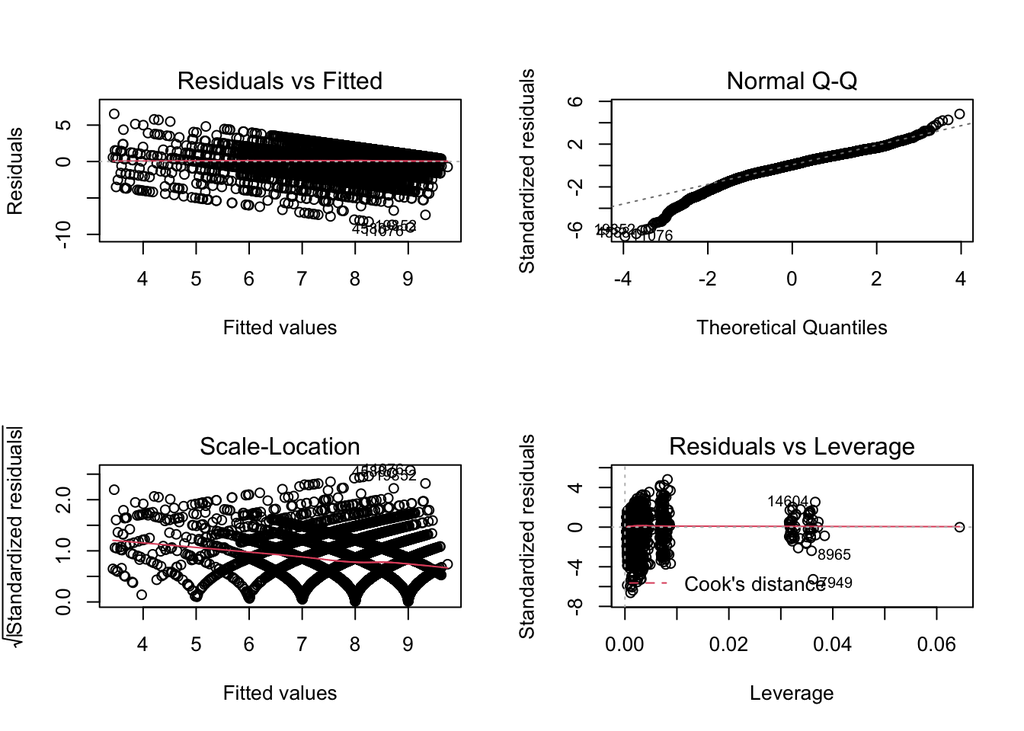

We have also done the diagnostic test to test whether the final model is good.

The model is strong in making inferences compared to previously proposed models because the p-values of almost all coefficients of estimators are statistically significant. However, a better inferential model accompanied by inaccurate predictions. Since the adjusted R-squared is 0.2858, which means approximately 29% variation of feelings_life (Happiness) is explained by the variation of independent variables in our regression model. In addition, the mean square error is increased compared to the original model and the temporarily best fit model selected by the likelihood ratio test. (The MSE for the initial model, likelihood selected model and the final model is listed below respectively).

```
## [1] 1.519688
```

```
## [1] 1.534305
```

```
## [1] 1.855016
```

Usually, model convergence requires iterations, and the iteration frequency is directly proportional to the accurate. Based on the knowledge we acquired so far, we are inadequate to perform the iterative process on our linear model. However, the major determinants of happiness in our model are mostly categorical variables and combine with poor performance in predicting as we discussed above. We are unconfident to propose that the model is convergent. Overall, our final model is sufficient in making inferences about the happiness of people but precision needs to be improved.

# Footnotes

[1] Explanation of the variables refers to footnotes. [2] Age in numerical value, not age groups. [3] The total number of children the respondent has. [4] The age of the first child in the sampling year (2017). [5] Male or female. [6] Ten provinces of Canada. [7] living common-law, married, separated, single never married, widowed, divorced. [8] Yes or No. [9] Less than high school diploma and its equivalent, High school diploma and its equivalent, College certificate and its equivalent, University certificate or diploma below the bachelor’s level, Bachelor’s degree, University certificate, Diploma or degree above bachelor’s level, Trade certificate or diploma. [10] Alone, Spouse only, Spouse and single child under 25 years of age, Spouse and single child 25 years of age or older, Spouse and other, Spouse and non-single child(ren), No spouse and non-single child(ren), No spouse and single child under 25 years of age, No spouse and single child 25 years of age or older, Living with one parent, Living with two parents, Other living arrangement. [11] 0.1 to 29.9 hours, 30.0 to 40.0 hours, 40.1 to 50.0 hours, 50.1 hours and more, Don’t know. [12] Excellent, Very good, Good, Fair, Poor, Don’t know. [13] Excellent, Very good, Good, Fair, Poor, Don’t know. [14] Less than $25,000, $25,000 to $49,999, $50,000 to $74,999, $75,000 to $99,999, $100,000 to $124,999, $125,000 and more. [15] Health Occupations, Management occupations, Natural and applied sciences and related occupations, Natural resources, agriculture and related production occupations, Occupations in art, culture, recreation and sport. Occupations in education, law and social community. Occupations in manufacturing and utilities, Sales and service occupations, Trades, transport and equipment operators and related occupations, Business, finance, and administration occupations, Uncodable.

## Result:

By combining our model result, we can conclude that people’s age, the number of their total children, the age of their first child, their marital status, self-rated health, and self-rated mental health will accept people’s feelings about life.

# graph of age

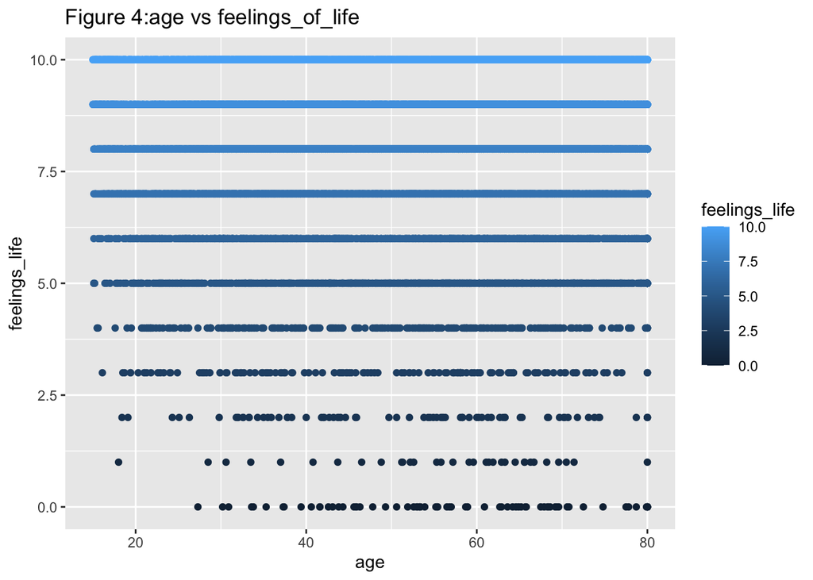

```
##
## Call:
## lm(formula = data$feelings_life ~ data$age)
##
## Residuals:
##     Min      1Q  Median      3Q     Max
## -8.2255 -0.9983 -0.0341  1.0162  2.0802
##
## Coefficients:
##              Estimate Std. Error t value Pr(>|t|)
## (Intercept) 7.8492259  0.0357581 219.509  < 2e-16 ***
## data$age    0.0047039  0.0006496   7.241 4.61e-13 ***
## ---
## Signif. codes:  0 '***' 0.001 '**' 0.01 '*' 0.05 '.' 0.1 ' ' 1
##
## Residual standard error: 1.643 on 20329 degrees of freedom
##   (271 observations deleted due to missingness)
## Multiple R-squared:  0.002573,   Adjusted R-squared:  0.002524
## F-statistic: 52.43 on 1 and 20329 DF,  p-value: 4.609e-13
```

# graph of total children

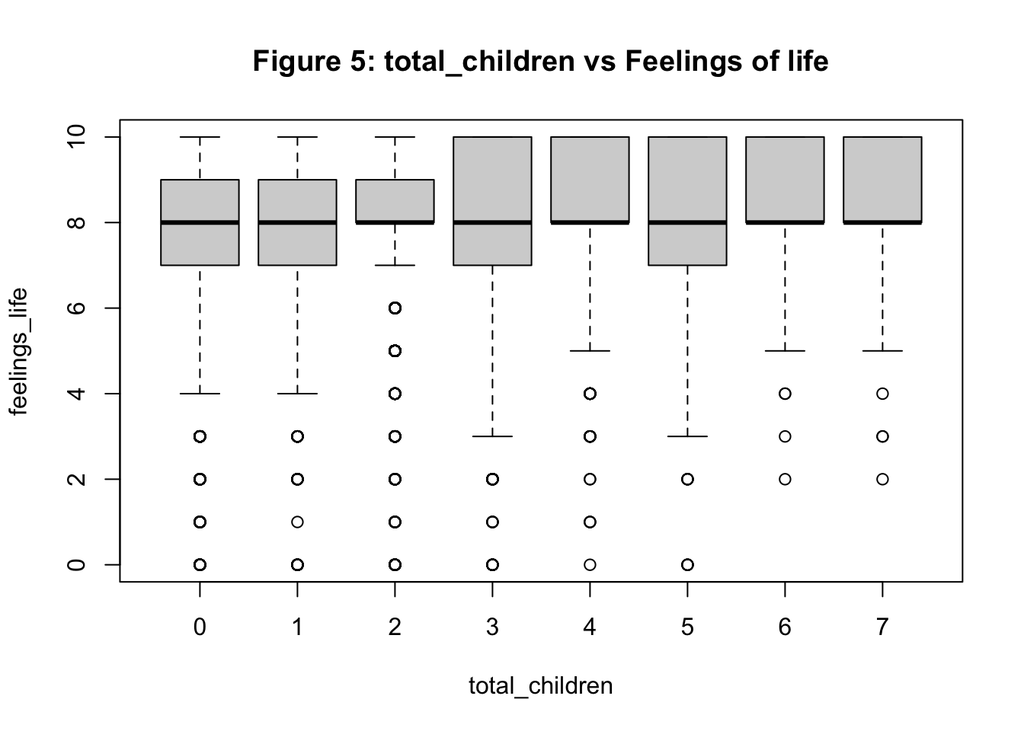

```
##
## Call:
## lm(formula = data1$feelings_life ~ data1$total_children)
##
## Residuals:
##     Min      1Q  Median      3Q     Max
## -8.4036 -0.9387  0.0613  1.0613  2.0613
##
## Coefficients:
##                      Estimate Std. Error t value Pr(>|t|)
## (Intercept)           7.93867    0.01732  458.50   <2e-16 ***
## data1$total_children  0.09298    0.00773   12.03   <2e-16 ***
## ---
## Signif. codes:  0 '***' 0.001 '**' 0.01 '*' 0.05 '.' 0.1 ' ' 1
##
## Residual standard error: 1.639 on 20310 degrees of freedom
##   (290 observations deleted due to missingness)
## Multiple R-squared:  0.007074,   Adjusted R-squared:  0.007025
## F-statistic: 144.7 on 1 and 20310 DF,  p-value: < 2.2e-16
```

# graph of age first child

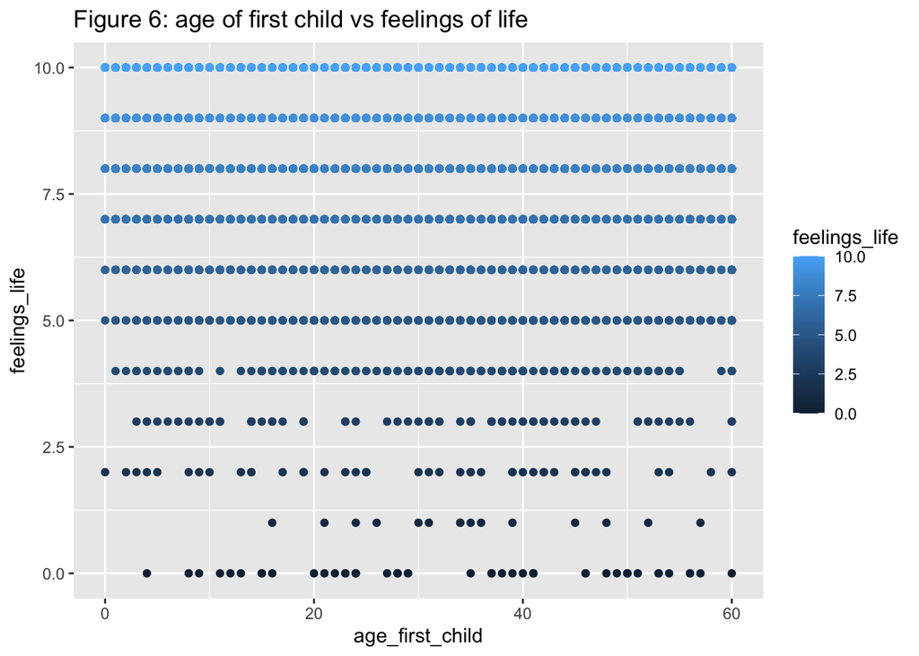

```
##
## Call:
## lm(formula = data1$feelings_life ~ data1$age_first_child)
##
## Residuals:
##     Min      1Q  Median      3Q     Max
## -8.2454 -1.1452 -0.1608  1.7546  1.8583
##
## Coefficients:
##                        Estimate Std. Error t value Pr(>|t|)
## (Intercept)           8.1417421  0.0283054 287.640   <2e-16 ***
## data1$age_first_child 0.0017284  0.0008096   2.135   0.0328 *
## ---
## Signif. codes:  0 '***' 0.001 '**' 0.01 '*' 0.05 '.' 0.1 ' ' 1
##
## Residual standard error: 1.612 on 13584 degrees of freedom
##   (7016 observations deleted due to missingness)
## Multiple R-squared:  0.0003354,  Adjusted R-squared:  0.0002618
## F-statistic: 4.558 on 1 and 13584 DF,  p-value: 0.03278
```

# graph of mariginal status

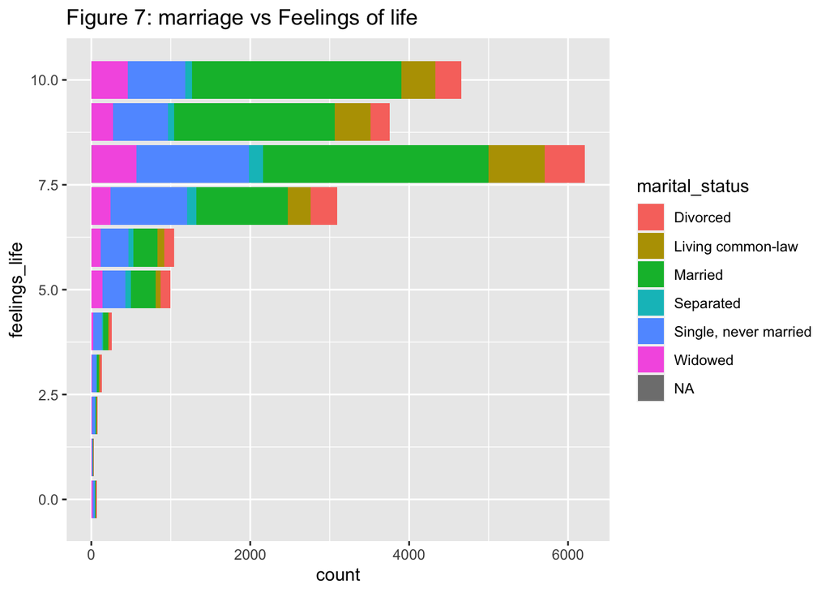

```
##
## Call:
## lm(formula = data1$feelings_life ~ data1$marital_status)
##
## Residuals:
##     Min      1Q  Median      3Q     Max
## -8.4329 -0.6721  0.3195  1.3279  2.6826
##
## Coefficients:
##                                            Estimate Std. Error t value Pr(>|t|)
## (Intercept)                                7.680460   0.038487 199.559  < 2e-16
## data1$marital_statusLiving common-law      0.540200   0.052261  10.337  < 2e-16
## data1$marital_statusMarried                0.752390   0.041904  17.955  < 2e-16
## data1$marital_statusSeparated             -0.363075   0.074779  -4.855 1.21e-06
## data1$marital_statusSingle, never married -0.008357   0.045104  -0.185    0.853
## data1$marital_statusWidowed                0.272615   0.053586   5.087 3.66e-07
##
## (Intercept)                               ***
## data1$marital_statusLiving common-law     ***
## data1$marital_statusMarried               ***
## data1$marital_statusSeparated             ***
## data1$marital_statusSingle, never married
## data1$marital_statusWidowed               ***
## ---
## Signif. codes:  0 '***' 0.001 '**' 0.01 '*' 0.05 '.' 0.1 ' ' 1
##
## Residual standard error: 1.605 on 20319 degrees of freedom
##   (277 observations deleted due to missingness)
## Multiple R-squared:  0.0482, Adjusted R-squared:  0.04797
## F-statistic: 205.8 on 5 and 20319 DF,  p-value: < 2.2e-16
```

We are interested in whether there is a connection between marital status and feelings of life. From the plot, the married people have occupied the larger part of the high score of people’s feelings of life index. Also, from the p-value table, it shows that almost every status of marriages has p-value less than 0.05 which shows that we reject the null hypothesis test about there is no connection between marital status and feelings of life.

# graph of self_rated_health and self_rated_mental_health

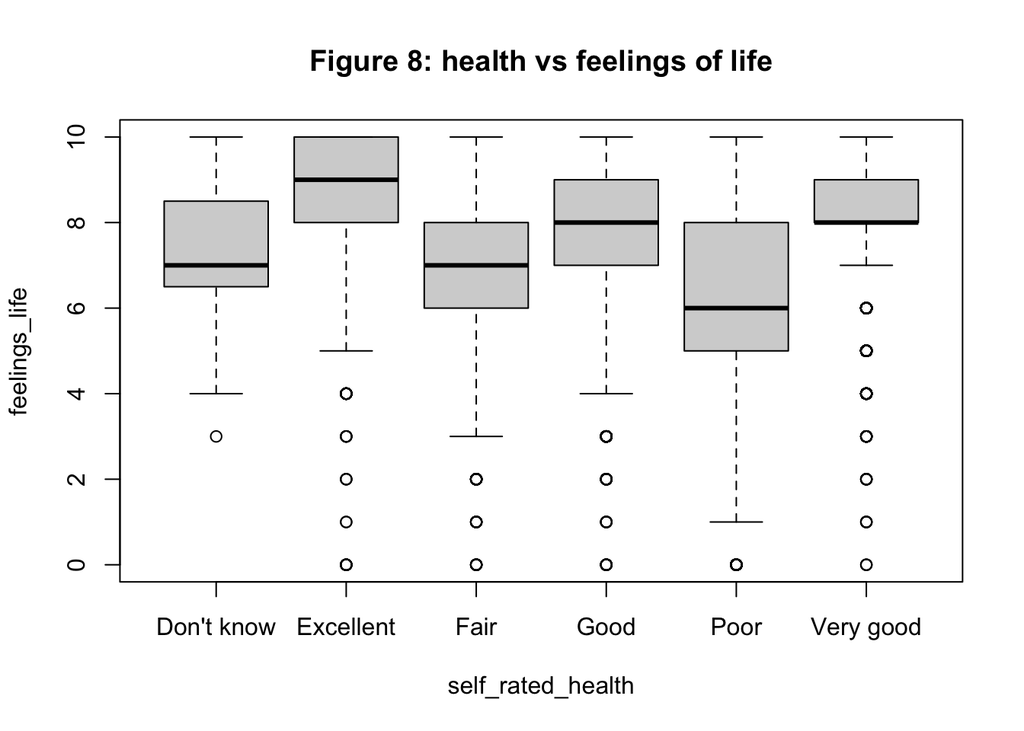

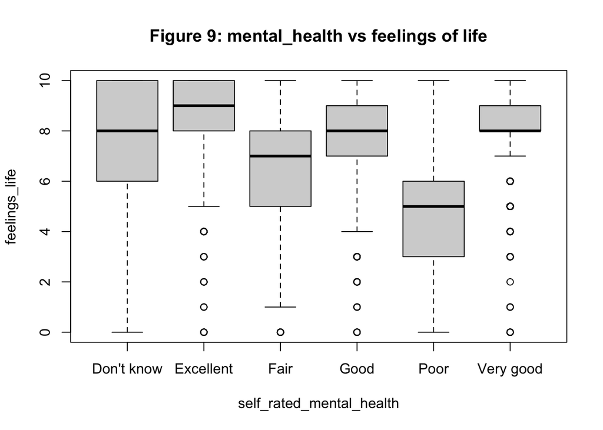

From the plot, we can see that the respondents whose body health and mental health are at excellent levels tend to be the happiest group on average. In addition, both plots reveal that the happiness index decreases as the body and mental health rate level lower down. Therefore, the variables “self_rated_health” and “self_rated_mental_health” are good indicators of happiness.

## Discussion：

We will explore relationships with happiness through six aspects: age, the total number of children, age of the first child, marital status, physical and mental health. The following six graphics can explain their correlation:

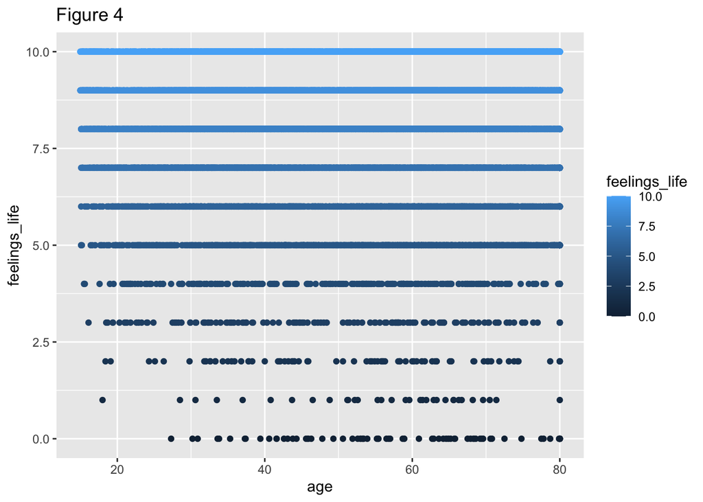

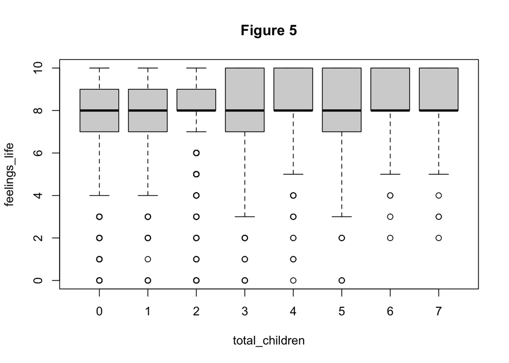

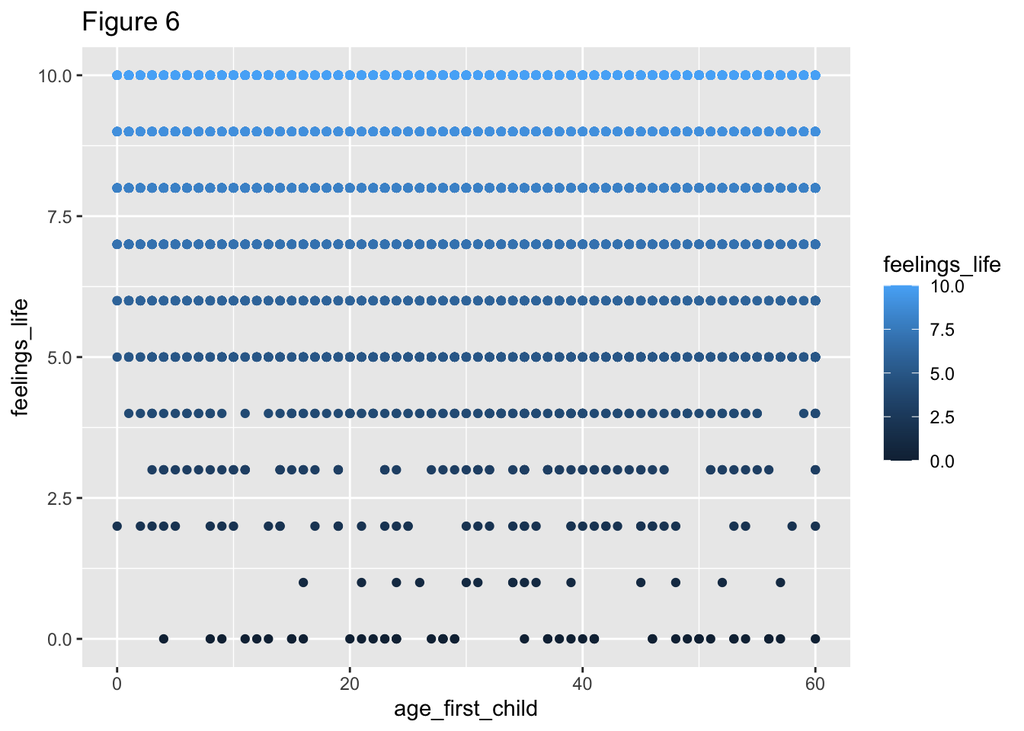

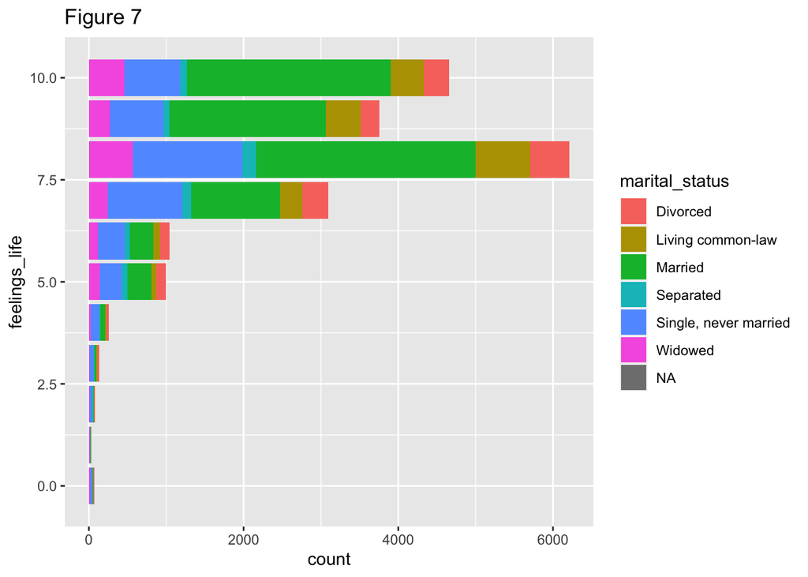

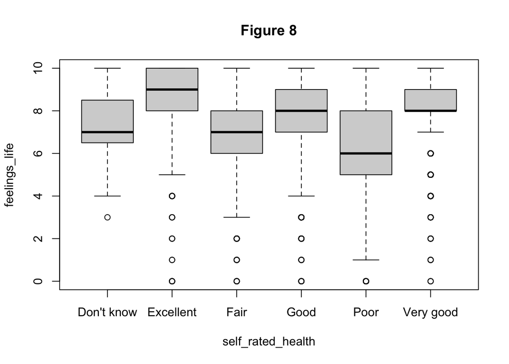

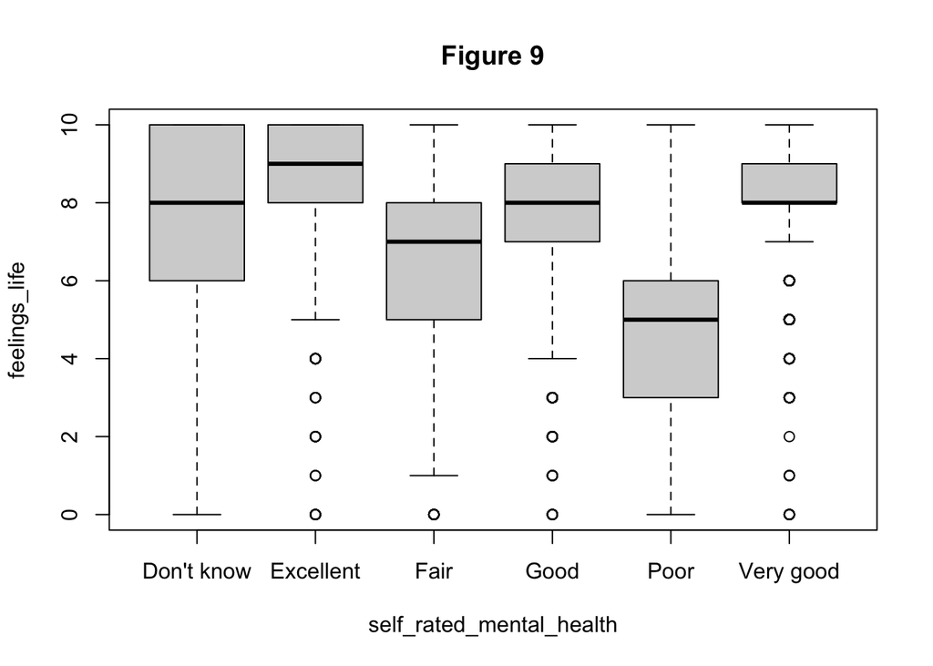

As we can see, Figure 4 shows the relationship between the age of respondents and feelings about life. Before the age of 27, most people’s happiness index is relatively high, and no one’s happiness index is 0, which means that before the age of 27, people feel life is happy, and there are no big worries. After the age of 27, people’s concerns may increase due to life pressure, family pressure, work pressure, etc. gradually, some people’s happiness index is 0. But if people can handle the problems well, they can improve their feelings about life.

Figure 6 can be used as a reference for people who have children or plan to have children. As the children get older, the feelings about life of the parents’ increases. Because before the child reaches adulthood, parents need to consider the child’s diet, daily life, and health. But after children reach adulthood, they need to be independent, take care of themselves, and be financially independent. Parents don’t have to worry about it, and then their feelings about life will increase.

It is often said that marriage is the grave of love and that falling in love will restrict people’s freedom. But based on Figure 7, we found some suggestions for people who are afraid of falling in love or getting married. According to the graph, people who get married and live by common law are happier than people who never married. This might because the feeling of accompaniment could make people feel happy. And marriage could make you feel not lonely. So if you want to be happier, you can find love bravely and get married boldly.

According to figure 8 and figure 9, people who do not have health problems either in the physical part or in the mental part are happier. If you are sick, you might have to go to the hospital and cure yourself. If your body is not in a healthy state, diseases will make you feel uncomfortable and you will not feel happy. The cost of going to the hospital may be unaffordable, which can also cause unhappiness. Mental health matters. People who have stressful lives or have depression will not be happy. People should really pay attention to the mental health problem because you will be unhappy.

## Weaknesses：

Firstly, the original dataset itself contains problems with the collecting ways. In this 2017 GSS model, they used telephone surveys. Telephone surveys could be considered as marketing fraud so people may not respond positively to questions or even hang up the phone. Also, this survey could not have responses from the family who do not have phones. The dataset itself contains weakness.

Secondly, the models we made have a small R square which is because the dataset itself has the collecting problem. R square gives us a percentage of variation in y’s explained regression line. It is bad to have a small R square.

Thirdly, the final model we made has a larger mean square error. And according to the R document that Daniel wrote, the mean square error measures the average of the squared of the errors. Low values of mean square error are a better fit model. Fourthly, we select the variable that we think matters to the happiness index which is a subjective choice without the scientific support.

Fifthly, we use ratio likelihood to test the model differences but the test is limited to the variables without NA, but in our variables, some NA have special meaning. For example, due to the target population of our sampling being people whose age are equal to or older than 15, the NA of age_first_child is because they are too young to have a child. We could not just simply remove NA that have special meanings. We did not find better ways to solve this problem.

## Next Steps：

We could learn better methods of making models to produce a better fit of the model.

We could improve the methods of collecting data from the survey.

We could learn how to deal with NA that have special meanings.

## References:

Alexander, R & Caetano, S (October 7, 2020). “gss_clean.R”. Retrieved from https://q.utoronto.ca/courses/184060/files/9422740?module_item_id=1867317

Beaupré, P. (April 2020). General Social Survey Cycle 31: Families Public Use Microdata File Documentation and User’s Guide, (Issue no. 2019001). Retrieved October 18, 2020, from Chass https://sda-artsci-utoronto-ca.myaccess.library.utoronto.ca/sdaweb/dli2/gss/gss31/gss31/more_doc/index.htm (need UTORid)

Daniel, L. Compute Model Quality. Retrieved October 17, 2020, from https://www.rdocumentation.org/packages/sjstats/versions/0.17.4/topics/cv

Esteban Ortiz-Ospina (2013) - “Happiness and Life Satisfaction”. Published online at OurWorldInData.org. Retrieved from https://ourworldindata.org/happiness-and-life-satisfaction

Lumley T (2020). “survey: analysis of complex survey samples.” R package version 4.0.

Lumley T (2004). “Analysis of Complex Survey Samples.” Journal of Statistical Software, 9(1), 1-19. R package version 2.2.

Lumley T (2010). Complex Surveys: A Guide to Analysis Using R: A Guide to Analysis Using R. John Wiley and Sons.

Kassambara, Visitor, & Mann, T. (2018, March 11). Linear Regression Assumptions and Diagnostics in R: Essentials. Retrieved October 20, 2020, from http://www.sthda.com/english/articles/39-regression-model-diagnostics/161-linear-regression-assumptions-and-diagnostics-in-r-essentials/

Mancini, C. (May 4, 2020). Advantages and disadvantages of a phone survey. Retrieved October 17, 2020, from https://www.idsurvey.com/en/advantages-and-disadvantages-of-phone-survey/

R Core Team(2020). R: A language and environment for statistical computing. R Foundation for Statistical Computing. Vienna, Austria. URL https://www.R-project.org/.

Wickham et al., (2019). Welcome to the tidyverse. Journal of Open Source Software, 4(43), 1686, https://doi.org/10.21105/joss.01686 Zeileis A, Hothorn T (2002). “Diagnostic Checking in Regression Relationships.” R News, 2(3), 7–10. https://CRAN.R-project.org/doc/Rnews/.